# Лабораторная работа №11

Настройка безопасного удалённого доступа по протоколу SSH

Агаева Зейнаб Фуад кызы

1032245473@rudn.ru

Российский университет дружбы народов

2026-10-27

# Цели и задачи работы

## Цель лабораторной работы

Получить практические навыки настройки безопасного удалённого доступа к серверу по протоколу `SSH`, ограничения доступа пользователей, настройки дополнительных TCP-портов, организации аутентификации по SSH-ключам, создания SSH-туннелей, удалённого выполнения консольных и графических приложений, а также автоматизации конфигурации SSH-сервера средствами `Vagrant`.

# Процесс выполнения лабораторной работы

## Проверяю удалённое подключение к серверу от имени root

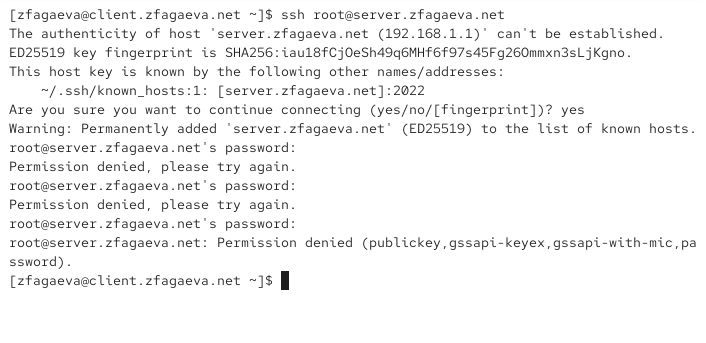

Проверка удалённого подключения к серверу по SSH от имени пользователя root

## Запрещаю удалённый доступ пользователю root

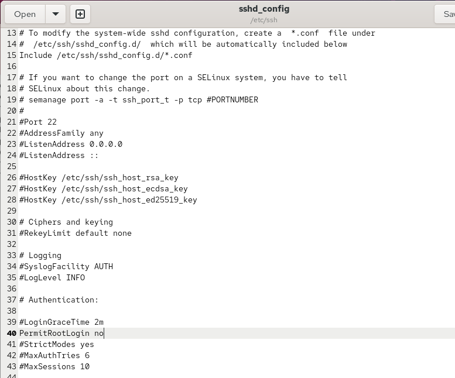

Запрет удалённого доступа пользователя root в конфигурационном файле SSH-сервера

## Проверяю запрет SSH-подключения пользователю root

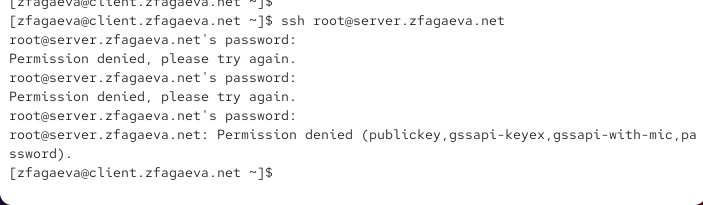

Проверка запрета SSH-подключения к серверу от имени пользователя root

## Проверяю подключение к серверу под пользователем zfagaeva

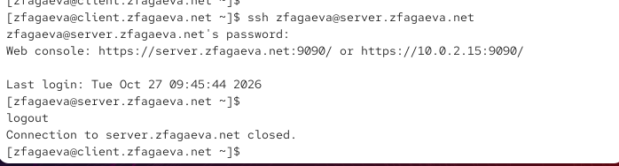

Проверка удалённого подключения к серверу под учётной записью zfagaeva

## Ограничиваю SSH-доступ только пользователем vagrant

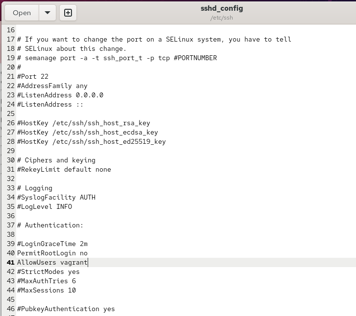

Ограничение удалённого SSH-доступа только пользователем vagrant

## Проверяю отказ в подключении пользователю zfagaeva

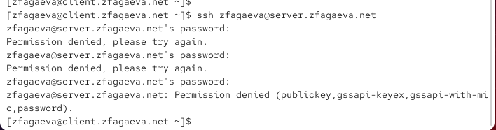

Проверка отказа в SSH-подключении пользователю, отсутствующему в списке AllowUsers

## Разрешаю SSH-доступ пользователям vagrant и zfagaeva

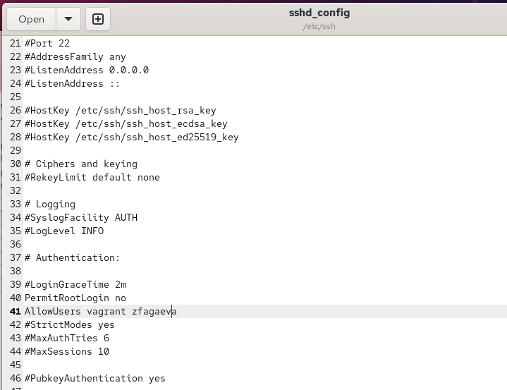

Настройка разрешённого списка пользователей vagrant и zfagaeva для SSH-доступа

## Проверяю подключение после изменения AllowUsers

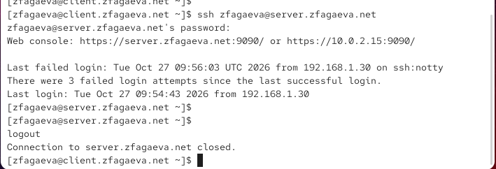

Проверка успешного SSH-подключения после добавления пользователя в список AllowUsers

## Настраиваю дополнительные порты SSH 22 и 2022

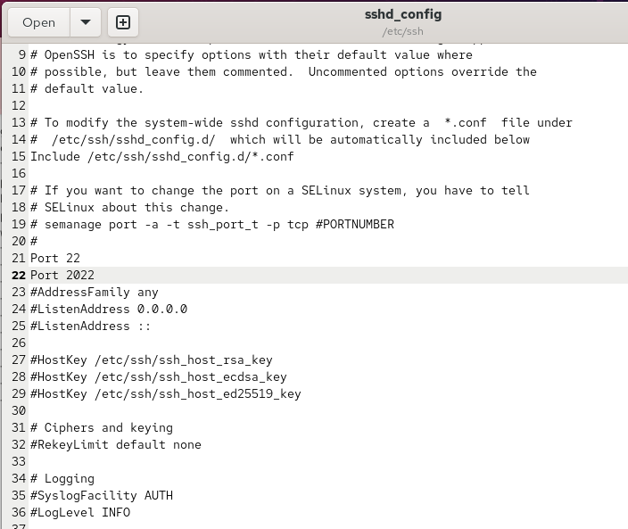

Настройка SSH-сервера для прослушивания TCP-портов 22 и 2022

## Проверяю состояние sshd и обнаруживаю ошибку доступа к порту 2022

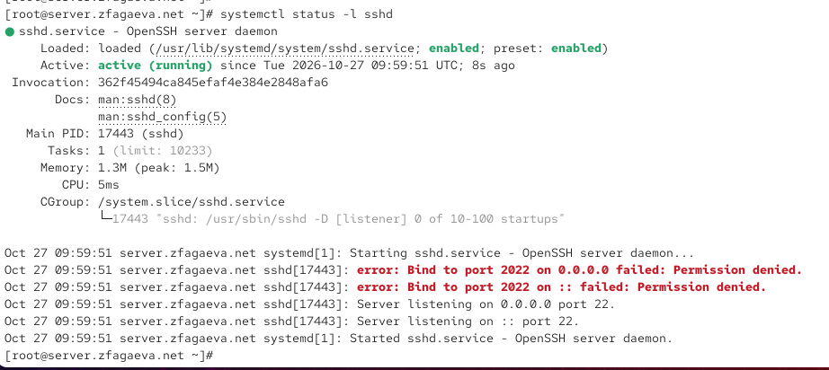

Проверка состояния службы sshd и обнаружение ошибки доступа к TCP-порту 2022

## Анализирую сообщения SELinux о блокировке порта 2022

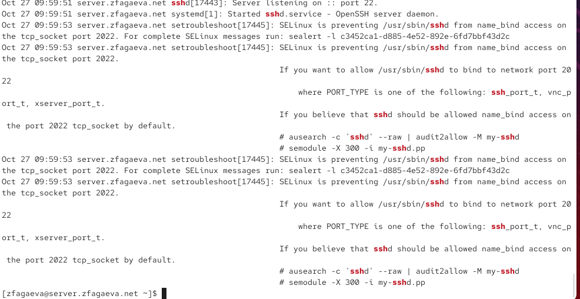

Анализ сообщений SELinux о запрете использования TCP-порта 2022 службой sshd

## Настраиваю SELinux и FirewallD для порта 2022

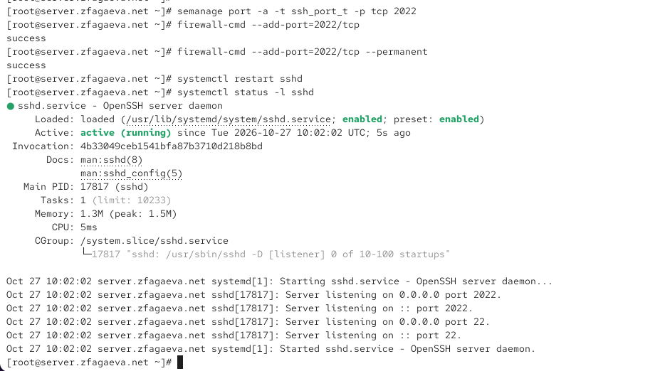

Настройка SELinux и межсетевого экрана для порта 2022 и проверка работы sshd

## Проверяю SSH-подключения через порты 22 и 2022

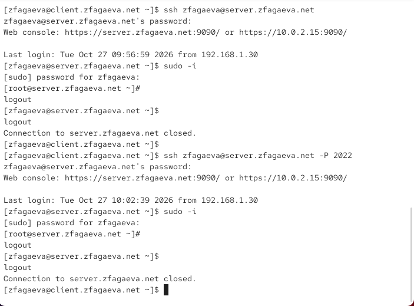

Проверка SSH-подключений через порты 22 и 2022 с получением прав суперпользователя

## Разрешаю аутентификацию пользователей по SSH-ключу

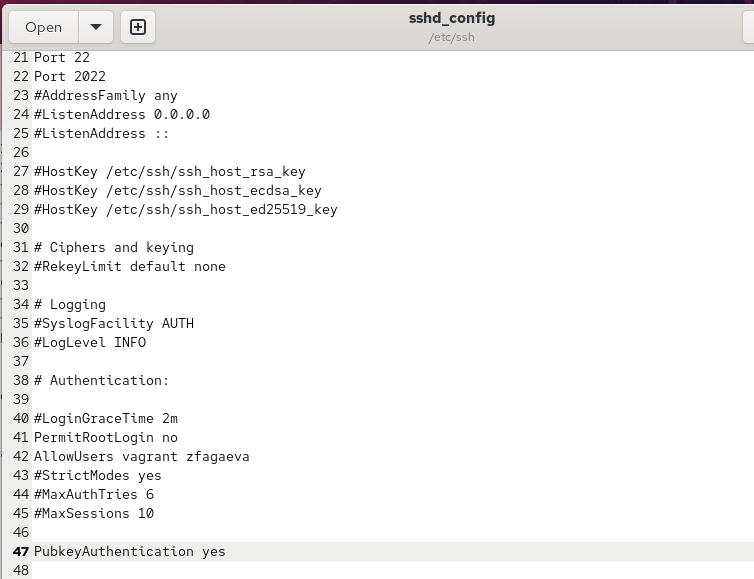

Разрешение аутентификации пользователей по открытому SSH-ключу

## Копирую открытый SSH-ключ и проверяю подключение без пароля

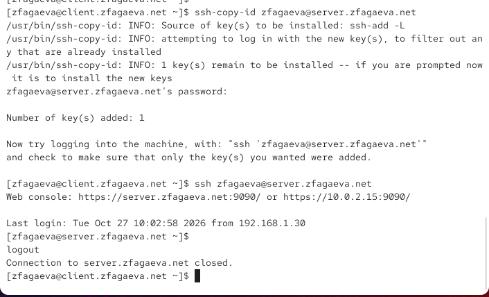

Копирование открытого SSH-ключа на сервер и проверка подключения без ввода пароля

## Создаю SSH-туннель с перенаправлением TCP-портов

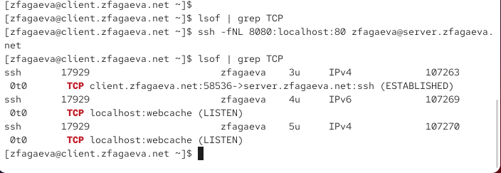

Создание SSH-туннеля с перенаправлением локального порта 8080 на порт 80 сервера

## Проверяю работу SSH-туннеля через веб-браузер

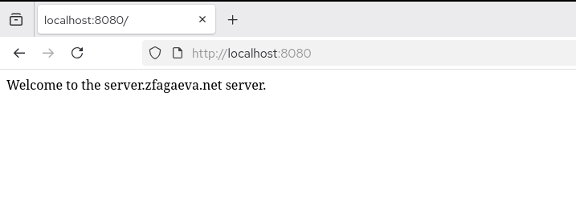

Проверка работы SSH-туннеля через браузер по адресу localhost:8080

## Выполняю консольные команды на сервере через SSH

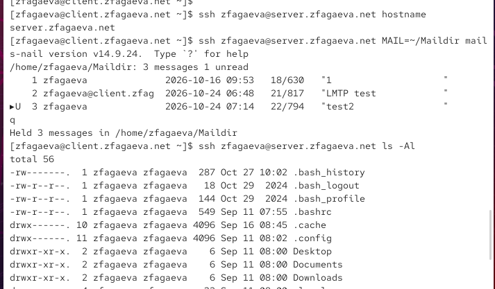

Удалённое выполнение команд hostname, mail и ls через SSH-соединение

## Разрешаю перенаправление графических приложений X11

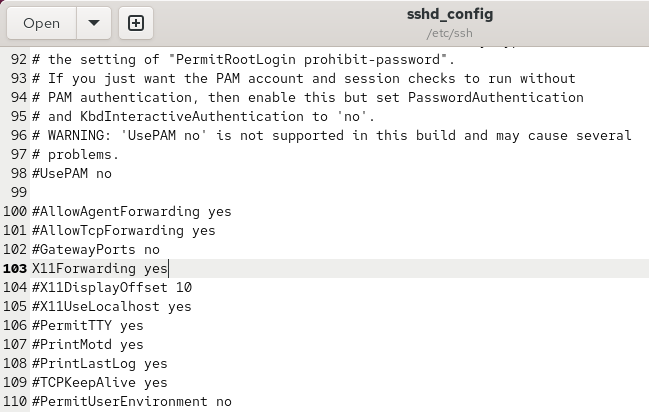

Разрешение перенаправления графических приложений X11 в конфигурации SSH-сервера

## Проверяю удалённый запуск Firefox через SSH

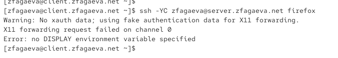

Попытка удалённого запуска Firefox через SSH и ошибка перенаправления X11

## Создаю скрипт автоматической настройки SSH-сервера

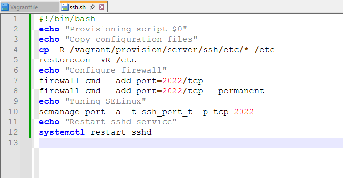

Создание скрипта ssh.sh для автоматической настройки SSH-сервера в окружении Vagrant

# Выводы по проделанной работе

## Вывод

В ходе лабораторной работы была выполнена настройка безопасного удалённого доступа к виртуальной машине `server` по протоколу `SSH`. В конфигурационном файле `/etc/ssh/sshd_config` запрещён удалённый вход пользователю `root` с помощью параметра `PermitRootLogin no`. Доступ к серверу ограничен учётными записями `vagrant` и `zfagaeva` с использованием директивы `AllowUsers`.

Настроена работа SSH-сервера через стандартный порт `22` и дополнительный порт `2022`. Для использования дополнительного порта внесены изменения в настройки `SELinux` и межсетевого экрана `FirewallD`. Работоспособность обоих портов подтверждена успешными SSH-подключениями с виртуальной машины `client`.

Настроена аутентификация по SSH-ключу с использованием параметра `PubkeyAuthentication yes`. Открытый ключ скопирован на сервер с помощью команды `ssh-copy-id`, после чего выполнено подключение без ввода пароля пользователя. Также организован SSH-туннель с перенаправлением локального порта `8080` на порт `80` сервера. Работа туннеля проверена открытием приветственной страницы веб-сервера в браузере клиента.